# Role of Methylation Quantitative Trait Loci in Shear Stress Susceptibility for Atherosclerosis

Ruben Methorst, Bsc**, Dr. Sander W. Van der Laan, Dr. Michal Mokry, Prof. dr. Gerard Pasterkamp

22-10-2019

## Introduction

Here we present the scripts and data corresponding with above stated publication. We performed several in silico analysis, including methylation quantitative trait loci (*cis*-mQTL) analysis using QTLtool v1.1 and Two Sample Mendelian Randomisation (2SMR) using TwoSampleMR v0.4.22.

Data was obtained from several sources. mQTL analysis was performed in genotyping and methylation data from the AtheroExpress Biobank<sup>1</sup>. 2SMR was performed using CARDIoGRAM+C4D<sup>2</sup> and METASTROKE<sup>3</sup> GWAS summary statistics.

## *cis*-mQTL analysis

*cis*-mQTL was perfomed using readily built scripts by S.W. Van der Laan, Associate Professor UMC Utrecht.

### Data preparation

We extracted our regions of interest from the Illumina 450k manifest file. Only looked at our 11 genes of interest and only at CpGs within -2000 TSS and 1st exon. A range of +/- 250kb was used on this region of interest to analyse for mQTLs using QTLtools<sup>4</sup>.

```r
library(readr)
library(data.table)

#read data

CPG <- read.delim("CPG.txt", header = FALSE)

Illumina450K <- read_csv("HumanMethylation450_15017482_v1-2.csv")

#extract genes of interest

IlluminaREGIONS <- Illumina450K[grep("KLF4|HOXA5|TMEM184B|ADAMTSL5|KLF3|CMKLR1|PKP4|ACVRL1|DOK4|SPRY2|ENOSF1",
                                  Illumina450K$UCSC_RefGene_Name), ]

Illumina_data <- IlluminaREGIONS[-grep("Body|3'UTR", IlluminaREGIONS$UCSC_RefGene_Group), ]

ROI <- data.frame(Illumina_data$IlmnID, Illumina_data$UCSC_RefGene_Name, Illumina_data$Chromosome_36, Illumina_data$Coordinate_36, Illumina_data$Coordinate_36, Illumina_data$Strand)

#Range, lead, trait column added

range <- numeric(157)

ROI["range"] <- range

ROI$range <- 250000


lead <- numeric(157)
ROI["lead"] <- lead

ROI$lead <- "new_lead"

trait <- numeric(157)
ROI["trait"] <- trait

ROI$trait <- "SS"

#prepare first row

ROI[1, 8] <- "previous_&_new_lead"

#to and from column added

ROI$from <- ROI$Illumina_data.Coordinate_36

ROI$to <- ROI$Illumina_data.Coordinate_36

#change names

colnames(ROI)[1:4] <- c("CpG", "Gene", "Chr", "Location")

#re-order

ROI2 <- ROI[c(1, 2, 3, 4, 10, 11, 7, 8, 9)]

#from to change values to TSS and -/+ 250kb

REGIONS <- ROI2

REGIONS$from[REGIONS$from %like% "^1590"] <- "158771722"
REGIONS$from[REGIONS$from %like% "^383"] <- "38092185"
REGIONS$from[REGIONS$from %like% "^271"] <- "27149812"
REGIONS$from[REGIONS$from %like% "^109"] <- "109291576"
REGIONS$from[REGIONS$from %like% "^107"] <- "107257216"
REGIONS$from[REGIONS$from %like% "^505"] <- "50342380"
REGIONS$from[REGIONS$from %like% "^798"] <- "79813087"
REGIONS$from[REGIONS$from %like% "^560"] <- "56077886"
REGIONS$from[REGIONS$from %like% "^702"] <- "702676"
REGIONS$from[REGIONS$from %like% "^703"] <- "702676"
REGIONS$from[REGIONS$from %like% "^146"] <- "1464019"
REGIONS$from[REGIONS$from %like% "^369"] <- "36998962"


REGIONS$to[REGIONS$to %like% "^1590"] <- "159021722"
REGIONS$to[REGIONS$to %like% "^383"] <- "38342185"
REGIONS$to[REGIONS$to %like% "^271"] <- "27399812"
REGIONS$to[REGIONS$to %like% "^109"] <- "109541576"
REGIONS$to[REGIONS$to %like% "^107"] <- "107507216"
REGIONS$to[REGIONS$to %like% "^505"] <- "50592380"
REGIONS$to[REGIONS$to %like% "^798"] <- "80063087"
REGIONS$to[REGIONS$to %like% "^560"] <- "56327886"
REGIONS$to[REGIONS$to %like% "^702"] <- "952676"
REGIONS$to[REGIONS$to %like% "^703"] <- "952676"
REGIONS$to[REGIONS$to %like% "^146"] <- "1714019"
REGIONS$to[REGIONS$to %like% "^369"] <- "37248962"

Inputfile <- REGIONS


#export

#write.table(ROI2, file = "ROI", sep = " ", row.names = FALSE, col.names = FALSE)
```

### Input data

```r
library(rmarkdown)

#install.packages("kableExtra")

library(kableExtra)

Inputfile %>%
  kable() %>%
  kable_styling(bootstrap_options = c("striped", "condensed"), font_size = 12, fixed_thead = T)
```

| CpG | Gene | Chr | Location | from | to | range | lead | trait |
| --- | --- | --- | --- | --- | --- | --- | --- | --- |
| cg00765721 | CCDC148;CCDC148;PKP4;PKP4 | 2 | 159022426 | 158771722 | 159021722 | 250000 | previous_&_new_lead | SS |
| cg00993543 | CCDC148;CCDC148;PKP4;PKP4 | 2 | 159021591 | 158771722 | 159021722 | 250000 | new_lead | SS |
| cg01775379 | PKP4;PKP4 | 2 | 159024510 | 158771722 | 159021722 | 250000 | new_lead | SS |
| cg02001814 | PKP4;CCDC148;PKP4;CCDC148;CCDC148;CCDC148 | 2 | 159021394 | 158771722 | 159021722 | 250000 | new_lead | SS |
| cg03264934 | CCDC148;CCDC148;PKP4;PKP4 | 2 | 159022989 | 158771722 | 159021722 | 250000 | new_lead | SS |
| cg04066396 | PKP4;PKP4 | 2 | 159023157 | 158771722 | 159021722 | 250000 | new_lead | SS |
| cg08444306 | CCDC148;CCDC148;PKP4;PKP4;PKP4;PKP4 | 2 | 159021825 | 158771722 | 159021722 | 250000 | new_lead | SS |
| cg08843298 | CCDC148;CCDC148;PKP4;PKP4 | 2 | 159021558 | 158771722 | 159021722 | 250000 | new_lead | SS |
| cg09072756 | PKP4;PKP4 | 2 | 159051937 | 158771722 | 159021722 | 250000 | new_lead | SS |
| cg10535786 | CCDC148;CCDC148;PKP4;PKP4 | 2 | 159021643 | 158771722 | 159021722 | 250000 | new_lead | SS |
| cg13896783 | CCDC148;CCDC148;PKP4;PKP4 | 2 | 159022122 | 158771722 | 159021722 | 250000 | new_lead | SS |
| cg17648451 | PKP4;PKP4 | 2 | 159094854 | 158771722 | 159021722 | 250000 | new_lead | SS |
| cg19840387 | CCDC148;CCDC148;PKP4;PKP4 | 2 | 159022262 | 158771722 | 159021722 | 250000 | new_lead | SS |
| cg20438915 | PKP4;PKP4 | 2 | 159025540 | 158771722 | 159021722 | 250000 | new_lead | SS |
| cg24519780 | PKP4;PKP4 | 2 | 159035659 | 158771722 | 159021722 | 250000 | new_lead | SS |
| cg27167195 | PKP4;PKP4 | 2 | 159087660 | 158771722 | 159021722 | 250000 | new_lead | SS |
| cg00033516 | FLJ13197;KLF3 | 4 | 38343168 | 38092185 | 38342185 | 250000 | new_lead | SS |
| cg05205842 | KLF3 | 4 | 38349525 | 38092185 | 38342185 | 250000 | new_lead | SS |
| cg05562080 | KLF3;FLJ13197 | 4 | 38342843 | 38092185 | 38342185 | 250000 | new_lead | SS |
| cg09915299 | FLJ13197;KLF3 | 4 | 38343058 | 38092185 | 38342185 | 250000 | new_lead | SS |
| cg14848077 | FLJ13197;KLF3 | 4 | 38343313 | 38092185 | 38342185 | 250000 | new_lead | SS |
| cg16471864 | KLF3;FLJ13197 | 4 | 38342665 | 38092185 | 38342185 | 250000 | new_lead | SS |
| cg17074863 | KLF3 | 4 | 38345149 | 38092185 | 38342185 | 250000 | new_lead | SS |
| cg18361445 | KLF3;FLJ13197 | 4 | 38342769 | 38092185 | 38342185 | 250000 | new_lead | SS |
| cg22453435 | FLJ13197;KLF3 | 4 | 38343825 | 38092185 | 38342185 | 250000 | new_lead | SS |
| cg24279243 | KLF3 | 4 | 38352954 | 38092185 | 38342185 | 250000 | new_lead | SS |
| cg27283052 | KLF3;FLJ13197 | 4 | 38342757 | 38092185 | 38342185 | 250000 | new_lead | SS |
| cg00969405 | HOXA5 | 7 | 27150966 | 27149812 | 27399812 | 250000 | new_lead | SS |
| cg01323381 | HOXA5 | 7 | 27150789 | 27149812 | 27399812 | 250000 | new_lead | SS |
| cg01370449 | HOXA5 | 7 | 27149894 | 27149812 | 27399812 | 250000 | new_lead | SS |

[output cut: 127 more lines]

### Results

#### Nominal results

Fraction of the filtered post QC-results (*full table available upon request*)

```r
library(readr)

plaque_mQTLs_region_nom_1 <- read.delim("V14_filtered/Nom_filter/aegs_QC_qtlnom_region_1_excl_DEFAULT_filtered1.nominal.all.txt",
                           dec = ".", sep = ",", header = TRUE)
plaque_mQTLs_region_nom_2 <- read.delim("V14_filtered/Nom_filter/aegs_QC_qtlnom_region_2_excl_DEFAULT_filtered1.nominal.all.txt",
                                    dec = ".", sep = ",", header = TRUE)
plaque_mQTLs_region_nom_3 <- read.delim("V14_filtered/Nom_filter/aegs_QC_qtlnom_region_3_excl_DEFAULT_filtered1.nominal.all.txt",
                                    dec = ".", sep = ",", header = TRUE)
plaque_mQTLs_region_nom_4 <- read.delim("V14_filtered/Nom_filter/aegs_QC_qtlnom_region_4_excl_DEFAULT_filtered1.nominal.all.txt",
                                    dec = ".", sep = ",", header = TRUE)
plaque_mQTLs_region_nom_5 <- read.delim("V14_filtered/Nom_filter/aegs_QC_qtlnom_region_5_excl_DEFAULT_filtered1.nominal.all.txt",
                                    dec = ".", sep = ",", header = TRUE)
plaque_mQTLs_region_nom_6 <- read.delim("V14_filtered/Nom_filter/aegs_QC_qtlnom_region_6_excl_DEFAULT_filtered1.nominal.all.txt",
                                    dec = ".", sep = ",", header = TRUE)
plaque_mQTLs_region_nom_7 <- read.delim("V14_filtered/Nom_filter/aegs_QC_qtlnom_region_7_excl_DEFAULT_filtered1.nominal.all.txt",
                                    dec = ".", sep = ",", header = TRUE)
plaque_mQTLs_region_nom_8 <- read.delim("V14_filtered/Nom_filter/aegs_QC_qtlnom_region_8_excl_DEFAULT_filtered1.nominal.all.txt",
                                    dec = ".", sep = ",", header = TRUE)
plaque_mQTLs_region_nom_9 <- read.delim("V14_filtered/Nom_filter/aegs_QC_qtlnom_region_9_excl_DEFAULT_filtered1.nominal.all.txt",
                                    dec = ".", sep = ",", header = TRUE)
plaque_mQTLs_region_nom_10 <- read.delim("V14_filtered/Nom_filter/aegs_QC_qtlnom_region_10_excl_DEFAULT_filtered1.nominal.all.txt",
                                    dec = ".", sep = ",", header = TRUE)
plaque_mQTLs_region_nom_11 <- read.delim("V14_filtered/Nom_filter/aegs_QC_qtlnom_region_11_excl_DEFAULT_filtered1.nominal.all.txt",
                                    dec = ".", sep = ",", header = TRUE)

mQTL_data_nom <- rbind(plaque_mQTLs_region_nom_1,
                       plaque_mQTLs_region_nom_2,
                       plaque_mQTLs_region_nom_3,
                       plaque_mQTLs_region_nom_4,
                       plaque_mQTLs_region_nom_5,
                       plaque_mQTLs_region_nom_6,
                       plaque_mQTLs_region_nom_7,
                       plaque_mQTLs_region_nom_8,
                       plaque_mQTLs_region_nom_9,
                       plaque_mQTLs_region_nom_10,
                       plaque_mQTLs_region_nom_11) #excluded the empty tables

# mQTL_data_nom %>%
#   DT::datatable(
#     extensions = 'Buttons',
#     options = list(dom = 'Bfrtip',
#                    buttons = c("csv")))

head(mQTL_data_nom) %>%
  kable() %>%
  kable_styling(bootstrap_options = c("striped", "condensed"), font_size = 12, fixed_thead = T)
```

ProbeID

VARIANT

Chr

BP

OtherAlleleB

CodedAlleleA

MAF

MAC

CAF

HWE

Info

Imputation

N

Distance_VARIANT_CpG

Strand

Chr_CpG

BP_CpG

ProbeType

GeneName_UCSC

AccessionID_UCSC

GeneGroup_UCSC

CpG_Island_Relation_UCSC

Phantom

DMR

Enhancer

HMM_Island

RegulatoryFeatureName

RegulatoryFeatureGroup

DHS

Beta

SE

Nominal_P

Bonferroni

BenjHoch

Q

cg02001814

rs57138240

2

159098318

C

T

0.243001

699.3569

0.2429993

1.000000

0.976290

imputed

1439

214831

2

159313148

II

PKP4;CCDC148

NM_003628;NM_001171637;NM_001005476;NM_138803

TSS1500;5’UTR;1stExon

N_Shore

NA

NA

NA

NA

2:159313051-159313550

Promoter_Associated

NA

-0.0535138

0.0254697

0.0178172

1

0.6617776

0.5789638

cg02001814

rs62176914

2

159100036

G

A

0.211915

609.8914

0.2119141

0.752112

0.970149

imputed

1439

213113

2

159313148

II

PKP4;CCDC148

NM_003628;NM_001171637;NM_001005476;NM_138803

TSS1500;5’UTR;1stExon

N_Shore

NA

NA

NA

NA

2:159313051-159313550

Promoter_Associated

NA

-0.0677336

0.0264189

0.0051762

1

0.6617776

0.5789638

cg02001814

rs62176915

2

159100056

G

A

0.243301

700.2203

0.2432994

1.000000

0.977324

imputed

1439

213093

2

159313148

II

PKP4;CCDC148

NM_003628;NM_001171637;NM_001005476;NM_138803

TSS1500;5’UTR;1stExon

N_Shore

NA

NA

NA

NA

2:159313051-159313550

Promoter_Associated

NA

-0.0517077

0.0256578

0.0219377

1

0.6617776

0.5789638

cg02001814

rs1521864

2

159105619

A

G

0.243219

699.9843

0.2432176

1.000000

0.977408

imputed

1439

207530

2

159313148

II

PKP4;CCDC148

NM_003628;NM_001171637;NM_001005476;NM_138803

TSS1500;5’UTR;1stExon

N_Shore

NA

NA

NA

NA

2:159313051-159313550

Promoter_Associated

NA

-0.0548425

0.0255553

0.0159351

1

0.6617776

0.5789638

cg02001814

rs2204085

2

159108615

G

A

0.243945

702.0737

0.7560479

1.000000

0.975969

imputed

1439

204534

2

159313148

II

PKP4;CCDC148

NM_003628;NM_001171637;NM_001005476;NM_138803

TSS1500;5’UTR;1stExon

N_Shore

NA

NA

NA

NA

2:159313051-159313550

Promoter_Associated

NA

0.0565400

0.0253971

0.0129990

1

0.6617776

0.5789638

cg02001814

rs17201554

2

159109868

T

C

0.243889

701.9125

0.2438871

1.000000

0.974146

imputed

1439

203281

2

159313148

II

PKP4;CCDC148

NM_003628;NM_001171637;NM_001005476;NM_138803

TSS1500;5’UTR;1stExon

N_Shore

NA

NA

NA

NA

2:159313051-159313550

Promoter_Associated

NA

-0.0537554

0.0257157

0.0182923

1

0.6617776

0.5789638

#### Permutation results

Filtered post QC-results

```r
library(readr)

plaque_mQTLs_region_1 <- read.delim("V14_filtered/Perm_filter/aegs_QC_qtlperm_region_1_excl_DEFAULT_filtered1.perm.Q0_05.txt",
                           dec = ".", sep = ",", header = TRUE)
plaque_mQTLs_region_2 <- read.delim("V14_filtered/Perm_filter/aegs_QC_qtlperm_region_2_excl_DEFAULT_filtered1.perm.Q0_05.txt",
                                    dec = ".", sep = ",", header = TRUE)
plaque_mQTLs_region_3 <- read.delim("V14_filtered/Perm_filter/aegs_QC_qtlperm_region_3_excl_DEFAULT_filtered1.perm.Q0_05.txt",
                                    dec = ".", sep = ",", header = TRUE)
plaque_mQTLs_region_4 <- read.delim("V14_filtered/Perm_filter/aegs_QC_qtlperm_region_4_excl_DEFAULT_filtered1.perm.Q0_05.txt",
                                    dec = ".", sep = ",", header = TRUE)
plaque_mQTLs_region_5 <- read.delim("V14_filtered/Perm_filter/aegs_QC_qtlperm_region_5_excl_DEFAULT_filtered1.perm.Q0_05.txt",
                                    dec = ".", sep = ",", header = TRUE)
plaque_mQTLs_region_6 <- read.delim("V14_filtered/Perm_filter/aegs_QC_qtlperm_region_6_excl_DEFAULT_filtered1.perm.Q0_05.txt",
                                    dec = ".", sep = ",", header = TRUE)
plaque_mQTLs_region_7 <- read.delim("V14_filtered/Perm_filter/aegs_QC_qtlperm_region_7_excl_DEFAULT_filtered1.perm.Q0_05.txt",
                                    dec = ".", sep = ",", header = TRUE)
plaque_mQTLs_region_8 <- read.delim("V14_filtered/Perm_filter/aegs_QC_qtlperm_region_8_excl_DEFAULT_filtered1.perm.Q0_05.txt",
                                    dec = ".", sep = ",", header = TRUE)
plaque_mQTLs_region_9 <- read.delim("V14_filtered/Perm_filter/aegs_QC_qtlperm_region_9_excl_DEFAULT_filtered1.perm.Q0_05.txt",
                                    dec = ".", sep = ",", header = TRUE)
plaque_mQTLs_region_10 <- read.delim("V14_filtered/Perm_filter/aegs_QC_qtlperm_region_10_excl_DEFAULT_filtered1.perm.Q0_05.txt",
                                    dec = ".", sep = ",", header = TRUE)
plaque_mQTLs_region_11 <- read.delim("V14_filtered/Perm_filter/aegs_QC_qtlperm_region_11_excl_DEFAULT_filtered1.perm.Q0_05.txt",
                                    dec = ".", sep = ",", header = TRUE)

mQTL_data <- rbind(plaque_mQTLs_region_2,
                   plaque_mQTLs_region_4,
                   plaque_mQTLs_region_5,
                   plaque_mQTLs_region_8,
                   plaque_mQTLs_region_9,
                   plaque_mQTLs_region_11) #excluded the empty tables

# mQTL_data %>%
#   DT::datatable(
#     extensions = 'Buttons',
#     options = list(dom = 'Bfrtip',
#                    buttons = c("csv")))


mQTL_data %>%
  kable() %>%
  kable_styling(bootstrap_options = c("striped", "condensed"), font_size = 12, fixed_thead = T)
```

ProbeID

VARIANT

Chr

BP

OtherAlleleB

CodedAlleleA

MAF

MAC

CAF

HWE

Info

Imputation

N

Distance_VARIANT_CpG

Strand

Chr_CpG

BP_CpG

ProbeType

GeneName_UCSC

AccessionID_UCSC

GeneGroup_UCSC

CpG_Island_Relation_UCSC

Phantom

DMR

Enhancer

HMM_Island

RegulatoryFeatureName

RegulatoryFeatureGroup

DHS

Beta

SE

Nominal_P

Perm_P

ApproxPerm_P

Bonferroni

BenjHoch

Q

cg18361445

rs140541063:38666372:AG:A

4

38666372

AG

A

0.116920

336.4958

0.1169204

0.1568120

0.972627

imputed

1439

2

4

38666374

I

KLF3;FLJ13197

NM_016531;NR_026804

5’UTR;TSS200

Island

NA

NA

NA

4:38341025-38343059

NA

NA

NA

0.9792980

0.0526593

0.00e+00

0.000999

0.0000000

0.0000000

0.0000000

Not_calculated._Throws_an_error_when_p-value_is_infinite_or_NA._NEED_FIXING

cg03267342

rs76747039

9

110453984

A

G

0.218512

628.8775

0.2185107

0.2160870

0.984697

imputed

1439

-201783

9

110252200

II

KLF4

NM_004235

TSS200

Island

NA

NA

NA

9:109291513-109292615

9:110251887-110252763

Unclassified

NA

0.1083370

0.0267571

2.57e-05

0.014985

0.0142344

0.0427032

0.0427032

Not_calculated._Throws_an_error_when_p-value_is_infinite_or_NA._NEED_FIXING

cg15448445

rs11113813

12

108710286

C

G

0.368015

1059.1472

0.6319781

0.3641960

0.983101

imputed

1439

-23023

12

108733308

I

CMKLR1

NM_001142344;NM_001142343;NM_004072

TSS1500

NA

NA

NA

TRUE

NA

NA

NA

NA

-0.2020580

0.0321773

0.00e+00

0.000999

0.0000005

0.0000068

0.0000068

Not_calculated._Throws_an_error_when_p-value_is_infinite_or_NA._NEED_FIXING

cg08110272

rs10861891

12

108710323

C

A

0.339210

976.2464

0.6607842

0.0392288

0.990258

imputed

1439

-22999

12

108733321

I

CMKLR1

NM_001142344;NM_001142343;NM_004072

TSS1500

NA

NA

NA

TRUE

NA

NA

NA

NA

-0.3066550

0.0523274

0.00e+00

0.000999

0.0000036

0.0000473

0.0000237

Not_calculated._Throws_an_error_when_p-value_is_infinite_or_NA._NEED_FIXING

cg03612522

rs4403843

12

108707829

A

G

0.337607

971.6329

0.6623773

0.0389722

0.968465

imputed

1439

25433

12

108733261

I

CMKLR1

NM_001142344;NM_004072;NM_001142343

TSS200

NA

NA

NA

TRUE

NA

NA

NA

NA

-0.1015470

0.0176779

0.00e+00

0.000999

0.0000114

0.0001482

0.0000494

Not_calculated._Throws_an_error_when_p-value_is_infinite_or_NA._NEED_FIXING

cg07919167

rs10861891

12

108710323

C

A

0.339210

976.2464

0.6607842

0.0392288

0.990258

imputed

1439

-4532

12

108714854

II

CMKLR1

NM_001142345;NM_001142343;NM_004072;NM_001142344

TSS1500;5’UTR

NA

NA

NA

TRUE

NA

NA

NA

NA

-0.0921326

0.0194137

1.00e-06

0.000999

0.0005304

0.0068949

0.0017237

Not_calculated._Throws_an_error_when_p-value_is_infinite_or_NA._NEED_FIXING

cg03408433

rs11113813

12

108710286

C

G

0.368015

1059.1472

0.6319781

0.3641960

0.983101

imputed

1439

-23085

12

108733370

II

CMKLR1

NM_001142344;NM_001142343;NM_004072

TSS1500

NA

NA

NA

TRUE

NA

NA

NA

NA

-0.1743490

0.0379347

2.20e-06

0.000999

0.0012101

0.0157312

0.0031462

Not_calculated._Throws_an_error_when_p-value_is_infinite_or_NA._NEED_FIXING

cg25832824

rs11113813

12

108710286

C

G

0.368015

1059.1472

0.6319781

0.3641960

0.983101

imputed

1439

22968

12

108733253

I

CMKLR1

NM_001142344;NM_004072;NM_001142343

TSS200

NA

NA

NA

TRUE

NA

NA

NA

NA

-0.0761448

0.0169974

3.70e-06

0.001998

0.0030173

0.0392248

0.0065375

Not_calculated._Throws_an_error_when_p-value_is_infinite_or_NA._NEED_FIXING

cg08471037

rs637718

16

57527946

A

G

0.235561

677.9446

0.7644319

0.2408150

0.964154

imputed

1439

-7540

16

57520405

I

DOK4

NM_018110

TSS200

NA

high-CpG:56077876-56077946

NA

NA

16:56077471-56078021

16:57519325-57521053

Promoter_Associated

NA

0.1044080

0.0165074

0.00e+00

0.000999

0.0000005

0.0000036

0.0000036

Not_calculated._Throws_an_error_when_p-value_is_infinite_or_NA._NEED_FIXING

cg07100532

rs7235957

18

717229

T

C

0.456227

1313.0213

0.5437682

0.4252850

0.979265

imputed

1439

4143

18

713085

II

ENOSF1

NM_202758;NM_001126123;NM_017512

TSS1500

Island

NA

NA

NA

NA

18:711414-713159

NonGene_Associated

NA

0.7936820

0.0543048

0.00e+00

0.000999

0.0000000

0.0000000

0.0000000

Not_calculated._Throws_an_error_when_p-value_is_infinite_or_NA._NEED_FIXING

cg26147554

rs7235957

18

717229

T

C

0.456227

1313.0213

0.5437682

0.4252850

0.979265

imputed

1439

4495

18

712733

I

ENOSF1

NM_017512;NM_001126123;NM_202758

TSS200;TSS1500

Island

NA

NA

NA

18:702233-703072

18:711414-713159

NonGene_Associated

NA

0.7524090

0.0576305

0.00e+00

0.000999

0.0000000

0.0000000

0.0000000

Not_calculated._Throws_an_error_when_p-value_is_infinite_or_NA._NEED_FIXING

cg00955482

rs2741188

18

708299

T

C

0.446472

1284.9464

0.5535278

0.6309560

0.989344

imputed

1439

-4439

18

712737

II

ENOSF1

NM_017512;NM_001126123;NM_202758

TSS200;TSS1500

Island

NA

NA

NA

18:702233-703072

18:711414-713159

NonGene_Associated

NA

0.2612630

0.0241870

0.00e+00

0.000999

0.0000000

0.0000000

0.0000000

Not_calculated._Throws_an_error_when_p-value_is_infinite_or_NA._NEED_FIXING

cg07283778

rs75588551

18

725330

A

G

0.121939

350.9404

0.1219382

0.9016260

0.970314

imputed

1439

-12534

18

712795

I

ENOSF1

NM_017512;NM_001126123;NM_202758

TSS200;TSS1500

Island

NA

NA

NA

18:702233-703072

18:711414-713159

NonGene_Associated

NA

0.1673330

0.0219264

0.00e+00

0.000999

0.0000000

0.0000000

0.0000000

Not_calculated._Throws_an_error_when_p-value_is_infinite_or_NA._NEED_FIXING

cg06456983

rs5750547

22

38546700

G

A

0.292220

841.0092

0.2922120

0.5666770

0.851400

imputed

1439

-122475

22

38669174

I

TMEM184B

NM_012264

TSS200

Island

NA

NA

NA

22:36998345-36999207

22:38668054-38669790

Promoter_Associated

NA

0.1128630

0.0256438

5.40e-06

0.003996

0.0021152

0.0253828

0.0253828

Not_calculated._Throws_an_error_when_p-value_is_infinite_or_NA._NEED_FIXING

## Two Sample MR analysis

mQTLs passing quality control were used for [2SMR analysis](https://mrcieu.github.io/TwoSampleMR/). These SNPs and SNPs in LD were identified in CARDIoGRAM+C4D and METASTROKE GWAS summary statistics using the TwoSampleMR tool<sup>5</sup> in R. Causility was determined with the passing SNPs.

### CARDIoGRAM+C4D

2SMR analysis of shear stress associated DNA methylation on CHD.

#### 2SMR and horizontal pleiotropy results

```r
#plaque MR analysis with CHD as outcome

#read mQTLs from QC data


library(readr)

plaque_mQTLs_region_1 <- read.delim("V14_filtered/Perm_filter/aegs_QC_qtlperm_region_1_excl_DEFAULT_filtered1.perm.Q0_05.txt",
                           dec = ".", sep = ",", header = TRUE)
plaque_mQTLs_region_2 <- read.delim("V14_filtered/Perm_filter/aegs_QC_qtlperm_region_2_excl_DEFAULT_filtered1.perm.Q0_05.txt",
                                    dec = ".", sep = ",", header = TRUE)
plaque_mQTLs_region_3 <- read.delim("V14_filtered/Perm_filter/aegs_QC_qtlperm_region_3_excl_DEFAULT_filtered1.perm.Q0_05.txt",
                                    dec = ".", sep = ",", header = TRUE)
plaque_mQTLs_region_4 <- read.delim("V14_filtered/Perm_filter/aegs_QC_qtlperm_region_4_excl_DEFAULT_filtered1.perm.Q0_05.txt",
                                    dec = ".", sep = ",", header = TRUE)
plaque_mQTLs_region_5 <- read.delim("V14_filtered/Perm_filter/aegs_QC_qtlperm_region_5_excl_DEFAULT_filtered1.perm.Q0_05.txt",
                                    dec = ".", sep = ",", header = TRUE)
plaque_mQTLs_region_6 <- read.delim("V14_filtered/Perm_filter/aegs_QC_qtlperm_region_6_excl_DEFAULT_filtered1.perm.Q0_05.txt",
                                    dec = ".", sep = ",", header = TRUE)
plaque_mQTLs_region_7 <- read.delim("V14_filtered/Perm_filter/aegs_QC_qtlperm_region_7_excl_DEFAULT_filtered1.perm.Q0_05.txt",
                                    dec = ".", sep = ",", header = TRUE)
plaque_mQTLs_region_8 <- read.delim("V14_filtered/Perm_filter/aegs_QC_qtlperm_region_8_excl_DEFAULT_filtered1.perm.Q0_05.txt",
                                    dec = ".", sep = ",", header = TRUE)
plaque_mQTLs_region_9 <- read.delim("V14_filtered/Perm_filter/aegs_QC_qtlperm_region_9_excl_DEFAULT_filtered1.perm.Q0_05.txt",
                                    dec = ".", sep = ",", header = TRUE)
plaque_mQTLs_region_10 <- read.delim("V14_filtered/Perm_filter/aegs_QC_qtlperm_region_10_excl_DEFAULT_filtered1.perm.Q0_05.txt",
                                    dec = ".", sep = ",", header = TRUE)
plaque_mQTLs_region_11 <- read.delim("V14_filtered/Perm_filter/aegs_QC_qtlperm_region_11_excl_DEFAULT_filtered1.perm.Q0_05.txt",
                                    dec = ".", sep = ",", header = TRUE)

mQTL_data <- rbind(plaque_mQTLs_region_2,
                   plaque_mQTLs_region_4,
                   plaque_mQTLs_region_5,
                   plaque_mQTLs_region_8,
                   plaque_mQTLs_region_9,
                   plaque_mQTLs_region_11) #excluded the empty tables


#2SMR analyse

library(TwoSampleMR)
library(MRInstruments)
data("gwas_catalog")

#read data manually

write.csv(mQTL_data, "mQTL_data.csv")

mQTL_exp_data <- read_exposure_data(
  filename = "mQTL_data.csv",
  sep = ",",
  snp_col = "VARIANT",
  beta_col = "Beta",
  se_col = "SE",
  effect_allele_col = "CodedAlleleA",
  other_allele_col = "OtherAlleleB",
  eaf_col = "MAF",
  pval_col = "ApproxPerm_P",
  samplesize_col = "N"
)
```

```
## No phenotype name specified, defaulting to 'exposure'.
```

```r
mQTL_exp_data$exposure <- "DNAm"


#GWAS summary statistics (CardioGRAM-C4D, coronary heart disease = outcome)

ao <- available_outcomes()
```

```
## 2019-10-30 17:20:27> Setting client.id from options(googleAuthR.client_id)
```

```r
CHD_out_data <- extract_instruments(outcomes = 7)
```

```
## Requesting default values. Extracting from pre-clumped data
```

```r
#clumping

mQTL_exp_data2 <- clump_data(mQTL_exp_data)
```

```
## Clumping 3EUWBw, 10 SNPs
```

```
## Removing the following SNPs due to LD with other SNPs:
## rs140541063:38666372:ag:a
## rs76747039
## rs10861891
## rs4403843
## rs2741188
## rs75588551
```

```r
#extract outcome data

mQTL_out_dat <- extract_outcome_data(
  snps = mQTL_exp_data2$SNP,
  outcomes = 7,
  proxies = TRUE
)
```

```
## Extracting data for 4 SNP(s) from 1 GWAS(s)
```

```r
#harmonize data

mQTL_vs_CHD <- harmonise_data(
  exposure_dat = mQTL_exp_data2,
  outcome_dat = mQTL_out_dat
)
```

```
## Harmonising DNAm (3EUWBw) and Coronary heart disease || id:7 (7)
```

```r
#MR analysis

mQTL_res <- mr(mQTL_vs_CHD)
```

```
## Analysing '3EUWBw' on '7'
```

```r
mQTL_res %>%
  kable() %>%
  kable_styling(bootstrap_options = c("striped", "condensed"), font_size = 12, fixed_thead = T)
```

| id.exposure | id.outcome | outcome | exposure | method | nsnp | b | se | pval |
| --- | --- | --- | --- | --- | --- | --- | --- | --- |
| 3EUWBw | 7 | Coronary heart disease \|\| id:7 | DNAm | MR Egger | 4 | 0.0053649 | 0.0168388 | 0.7802201 |
| 3EUWBw | 7 | Coronary heart disease \|\| id:7 | DNAm | Weighted median | 4 | 0.0015147 | 0.0111695 | 0.8921271 |
| 3EUWBw | 7 | Coronary heart disease \|\| id:7 | DNAm | Inverse variance weighted | 4 | 0.0004566 | 0.0114295 | 0.9681342 |
| 3EUWBw | 7 | Coronary heart disease \|\| id:7 | DNAm | Simple mode | 4 | 0.0066274 | 0.0234747 | 0.7960537 |
| 3EUWBw | 7 | Coronary heart disease \|\| id:7 | DNAm | Weighted mode | 4 | 0.0012669 | 0.0127287 | 0.9269975 |

```r
#write.table(mQTL_res,"MR_results_plaque.txt",row.names=TRUE, sep = ",", dec = ".")

#horizontal pleiotropy

hor_plei <- mr_pleiotropy_test(mQTL_vs_CHD)

hor_plei %>%
  kable() %>%
  kable_styling(bootstrap_options = c("striped", "condensed"), font_size = 12, fixed_thead = T)
```

| id.exposure | id.outcome | outcome | exposure | egger_intercept | se | pval |
| --- | --- | --- | --- | --- | --- | --- |
| 3EUWBw | 7 | Coronary heart disease \|\| id:7 | DNAm | -0.0029035 | 0.0073148 | 0.7297693 |

```r
#write.table(hor_plei,"horizontal_pleio_plaque.txt",row.names=TRUE, sep = ",", dec = ".")
```

#### Scatter plot and forest plot with passing SNPs

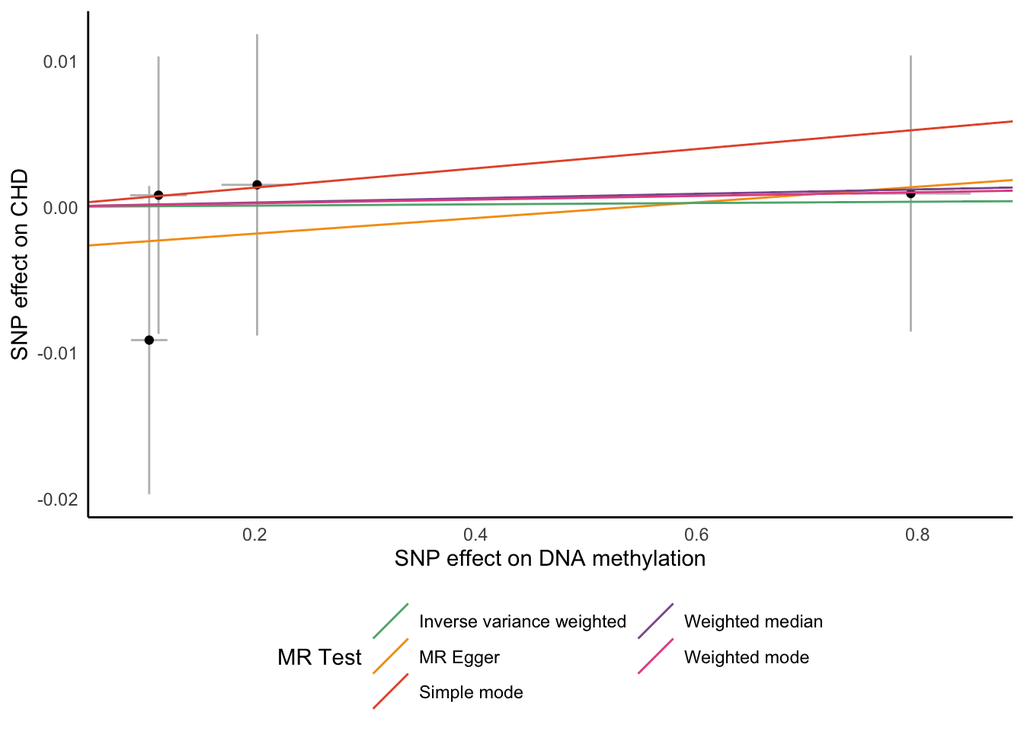

```r
library(ggplot2)

PLOT <- mr_scatter_plot(mQTL_res, mQTL_vs_CHD)

#to make the plot my own the identifier needs to be named value

plotlot <- mQTL_res[1,1]
plotlot1 <- ".7"

plottype <- paste0(plotlot, plotlot1)

#minimal theme incl. no grid lines & black axis lines

PLOT3 <- PLOT[[plottype]] +
  theme_minimal() +
  theme(legend.position="bottom",
        panel.background = element_rect(fill = "#FFFFFF",
                                        colour = "#FFFFFF"),
        panel.grid.major = element_blank(),
        panel.grid.minor = element_blank(),
        axis.line = element_line(colour = "black")) +
  labs(x = "SNP effect on DNA methylation") +
  labs(y = "SNP effect on CHD") +
  scale_color_manual(values=c("#5EB17F","#F59D10","#E55738","#8D5B9A","#E35493"))

plot(PLOT3)
```

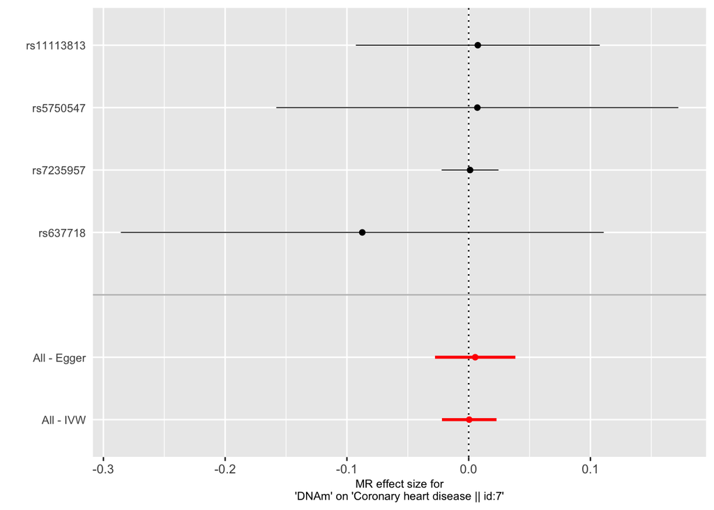

```r
#FOREST PLOT

res_single <- mr_singlesnp(mQTL_vs_CHD)
p2 <- mr_forest_plot(res_single)
p2[[1]]
```

### METASTROKE

2SMR analysis of shear stress associated DNA methylation on Stroke

#### 2SMR and horizontal pleiotropy results

```r
#plaque MR analysis with stroke as outcome

#read mQTLs from QC data


library(readr)

plaque_mQTLs_region_1 <- read.delim("V14_filtered/Perm_filter/aegs_QC_qtlperm_region_1_excl_DEFAULT_filtered1.perm.Q0_05.txt",
                           dec = ".", sep = ",", header = TRUE)
plaque_mQTLs_region_2 <- read.delim("V14_filtered/Perm_filter/aegs_QC_qtlperm_region_2_excl_DEFAULT_filtered1.perm.Q0_05.txt",
                                    dec = ".", sep = ",", header = TRUE)
plaque_mQTLs_region_3 <- read.delim("V14_filtered/Perm_filter/aegs_QC_qtlperm_region_3_excl_DEFAULT_filtered1.perm.Q0_05.txt",
                                    dec = ".", sep = ",", header = TRUE)
plaque_mQTLs_region_4 <- read.delim("V14_filtered/Perm_filter/aegs_QC_qtlperm_region_4_excl_DEFAULT_filtered1.perm.Q0_05.txt",
                                    dec = ".", sep = ",", header = TRUE)
plaque_mQTLs_region_5 <- read.delim("V14_filtered/Perm_filter/aegs_QC_qtlperm_region_5_excl_DEFAULT_filtered1.perm.Q0_05.txt",
                                    dec = ".", sep = ",", header = TRUE)
plaque_mQTLs_region_6 <- read.delim("V14_filtered/Perm_filter/aegs_QC_qtlperm_region_6_excl_DEFAULT_filtered1.perm.Q0_05.txt",
                                    dec = ".", sep = ",", header = TRUE)
plaque_mQTLs_region_7 <- read.delim("V14_filtered/Perm_filter/aegs_QC_qtlperm_region_7_excl_DEFAULT_filtered1.perm.Q0_05.txt",
                                    dec = ".", sep = ",", header = TRUE)
plaque_mQTLs_region_8 <- read.delim("V14_filtered/Perm_filter/aegs_QC_qtlperm_region_8_excl_DEFAULT_filtered1.perm.Q0_05.txt",
                                    dec = ".", sep = ",", header = TRUE)
plaque_mQTLs_region_9 <- read.delim("V14_filtered/Perm_filter/aegs_QC_qtlperm_region_9_excl_DEFAULT_filtered1.perm.Q0_05.txt",
                                    dec = ".", sep = ",", header = TRUE)
plaque_mQTLs_region_10 <- read.delim("V14_filtered/Perm_filter/aegs_QC_qtlperm_region_10_excl_DEFAULT_filtered1.perm.Q0_05.txt",
                                    dec = ".", sep = ",", header = TRUE)
plaque_mQTLs_region_11 <- read.delim("V14_filtered/Perm_filter/aegs_QC_qtlperm_region_11_excl_DEFAULT_filtered1.perm.Q0_05.txt",
                                    dec = ".", sep = ",", header = TRUE)

mQTL_data <- rbind(plaque_mQTLs_region_2,
                   plaque_mQTLs_region_4,
                   plaque_mQTLs_region_5,
                   plaque_mQTLs_region_8,
                   plaque_mQTLs_region_9,
                   plaque_mQTLs_region_11) #excluded the empty tables

#2SMR analyse

library(TwoSampleMR)
library(MRInstruments)
data("gwas_catalog")

#read data

write.csv(mQTL_data, "mQTL_data.csv")

mQTL_exp_data <- read_exposure_data(
  filename = "mQTL_data.csv",
  sep = ",",
  snp_col = "VARIANT",
  beta_col = "Beta",
  se_col = "SE",
  effect_allele_col = "CodedAlleleA",
  other_allele_col = "OtherAlleleB",
  eaf_col = "MAF",
  pval_col = "ApproxPerm_P",
  samplesize_col = "N"
)
```

```
## No phenotype name specified, defaulting to 'exposure'.
```

```r
mQTL_exp_data$exposure <- "DNAm"

#GWAS summary statistics (METASTROKE, stroke = outcome)

#ao <- available_outcomes()


IS_out_data <- extract_instruments(outcomes = 1108)
```

```
## Requesting default values. Extracting from pre-clumped data
```

```r
#clumping

mQTL_exp_data2 <- clump_data(mQTL_exp_data)
```

```
## Clumping 40ZFmj, 10 SNPs
```

```
## Removing the following SNPs due to LD with other SNPs:
## rs140541063:38666372:ag:a
## rs76747039
## rs10861891
## rs4403843
## rs2741188
## rs75588551
```

```r
#extract outcome data

mQTL_out_dat <- extract_outcome_data(
  snps = mQTL_exp_data2$SNP,
  outcomes = 1108,
  proxies = TRUE
)
```

```
## Extracting data for 4 SNP(s) from 1 GWAS(s)
```

```
## Finding proxies for 3 SNPs in outcome 1108
```

```
## Extracting data for 3 SNP(s) from 1 GWAS(s)
```

```r
#harmonize data

mQTL_vs_IS <- harmonise_data(
  exposure_dat = mQTL_exp_data2,
  outcome_dat = mQTL_out_dat
)
```

```
## Harmonising DNAm (40ZFmj) and Ischemic stroke || id:1108 (1108)
```

```r
#MR analysis

mQTL_res_IS <- mr(mQTL_vs_IS)
```

```
## Analysing '40ZFmj' on '1108'
```

```r
mQTL_res_IS %>%
  kable() %>%
  kable_styling(bootstrap_options = c("striped", "condensed"), font_size = 12, fixed_thead = T)
```

| id.exposure | id.outcome | outcome | exposure | method | nsnp | b | se | pval |
| --- | --- | --- | --- | --- | --- | --- | --- | --- |
| 40ZFmj | 1108 | Ischemic stroke \|\| id:1108 | DNAm | MR Egger | 3 | -0.0491483 | 0.0322006 | 0.3692412 |
| 40ZFmj | 1108 | Ischemic stroke \|\| id:1108 | DNAm | Weighted median | 3 | -0.0253838 | 0.0219736 | 0.2480099 |
| 40ZFmj | 1108 | Ischemic stroke \|\| id:1108 | DNAm | Inverse variance weighted | 3 | -0.0220948 | 0.0203555 | 0.2777235 |
| 40ZFmj | 1108 | Ischemic stroke \|\| id:1108 | DNAm | Simple mode | 3 | 0.0162135 | 0.0552540 | 0.7968368 |
| 40ZFmj | 1108 | Ischemic stroke \|\| id:1108 | DNAm | Weighted mode | 3 | -0.0288089 | 0.0212298 | 0.3076382 |

```r
#write.table(mQTL_res,"MR_results_plaque.txt",row.names=TRUE, sep = ",", dec = ".")

#horizontal pleiotropy

hor_plei <- mr_pleiotropy_test(mQTL_vs_IS)

hor_plei %>%
  kable() %>%
  kable_styling(bootstrap_options = c("striped", "condensed"), font_size = 12, fixed_thead = T)
```

| id.exposure | id.outcome | outcome | exposure | egger_intercept | se | pval |
| --- | --- | --- | --- | --- | --- | --- |
| 40ZFmj | 1108 | Ischemic stroke \|\| id:1108 | DNAm | 0.0167972 | 0.0154916 | 0.4742712 |

```r
#write.table(hor_plei,"horizontal_pleio_plaque.txt",row.names=TRUE, sep = ",", dec = ".")
```

#### Scatter plot and forest plot with passing SNPs

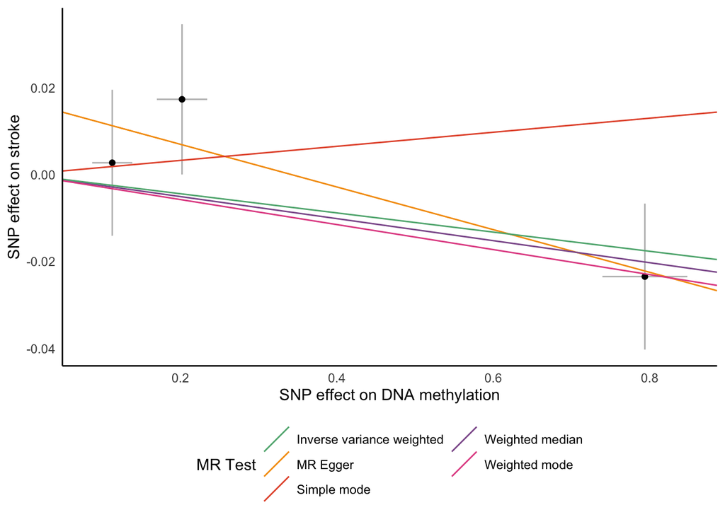

```r
#MR plot
PLOT2 <- mr_scatter_plot(mQTL_res_IS, mQTL_vs_IS)

#to make the plot my own the identifier needs to be named value

plotlot2 <- mQTL_res_IS[1,1]
plotlot.2 <- ".1108"

plottype2 <- paste0(plotlot2, plotlot.2)

#minimal theme incl. no grid lines & black axis lines

PLOT4 <- PLOT2[[plottype2]] +
  theme_minimal() +
  theme(legend.position="bottom",
        panel.background = element_rect(fill = "#FFFFFF",
                                        colour = "#FFFFFF"),
        panel.grid.major = element_blank(),
        panel.grid.minor = element_blank(),
        axis.line = element_line(colour = "black")) +
  labs(x = "SNP effect on DNA methylation") +
  labs(y = "SNP effect on stroke") +
  scale_color_manual(values=c("#5EB17F","#F59D10","#E55738","#8D5B9A","#E35493"))

plot(PLOT4)
```

[figure not shown]

```r
#FOREST PLOT

res_single <- mr_singlesnp(mQTL_vs_CHD)
p2 <- mr_forest_plot(res_single)
p2[[1]]
```

## Regional Association Plot KLF3

We made the regional association plot of the KLF3 region using Regional Association ComparER (RACER) v0.1 of [oliviasabik](https://github.com/oliviasabik/RACER).

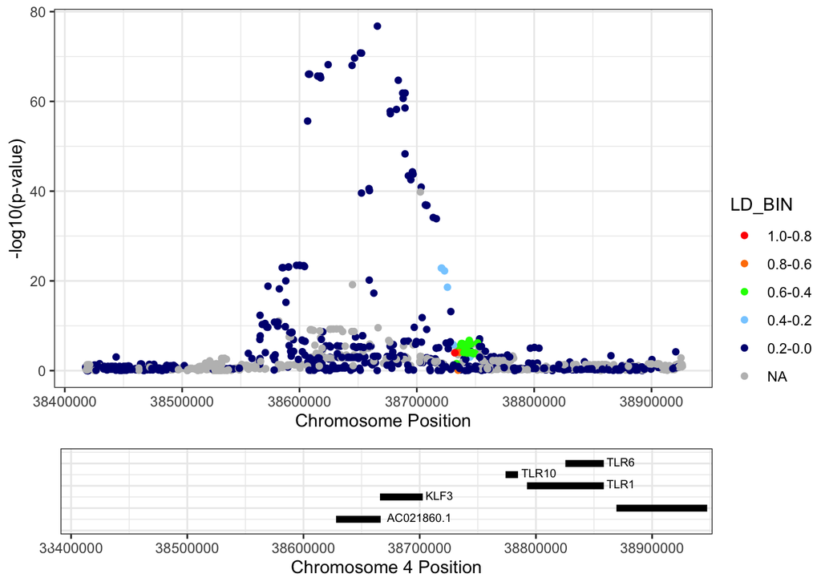

```r
#Download & Install RACER tool
# install.packages("devtools")
# library(devtools)
# install_github("oliviasabik/RACER")
  library(RACER)


library(readr)
library(dplyr)

#read data

RAP_data_1 <- read_delim("LocusZoom data 1.csv",
                               ";", escape_double = FALSE, trim_ws = TRUE)


RAP_data_1[,-1] <- gsub("\\:.*", "", as.matrix(RAP_data_1[,-1]))

RAP_data_1 <- RAP_data_1[grepl("cg18361445", RAP_data_1$ProbeID), ]


RAP_data_1$Nominal_P <- as.numeric(gsub(",", ".", RAP_data_1$Nominal_P))

#Regional association plot

mQTLs_plot <- RACER::formatRACER(assoc_data = RAP_data_1,
                                 chr_col = 3,
                                 pos_col = 4,
                                 p_col = 32)

#Add LD data

mQTLs_plot_2 <- RACER::ldRACER(assoc_data = mQTLs_plot,
                               rs_col = 2, pops = "EUR",
                               lead_snp = "rs7660114")

#plotting data

mQTLs_plot_3 <- mQTLs_plot_2[mQTLs_plot_2$LOG10P > 0, ]

RACER::singlePlotRACER(assoc_data = mQTLs_plot_3,
                       chr = 4,
                       build = "hg19",
                       plotby = "coord",
                       start_plot = 38416416,
                       end_plot = 38926476)
```

```r
#write.table(LocusZoom_data_1, file = "Locuszoom_data_region_KLF3.txt", row.names = F, quote = F, sep = "\t")
```

## References

1. Verhoeven, B. A. N. et al. Athero-express: differential atherosclerotic plaque expression of mRNA and protein in relation to cardiovascular events and patient characteristics. Rationale and design. Eur. J. Epidemiol. 19, 1127–1133 (2004)
2. Nikpay, M. et al. A comprehensive 1,000 Genomes-based genome-wide association meta-analysis of coronary artery disease. Nat. Genet. 47, 1121–1130 (2015)
3. Malik, R. et al. Low-frequency and common genetic variation in ischemic stroke: The METASTROKE collaboration. Neurology 86, 1217–1226 (2016)
4. Delaneau, O. et al. A complete tool set for molecular QTL discovery and analysis. Nat Commun 8, 15452 (2017)
5. Davey Smith, G. & Hemani, G. Mendelian randomization: genetic anchors for causal inference in epidemiological studies. Hum. Mol. Genet. 23, R89-98 (2014)

| <sup>© 1998-2019 Ruben Methorst \| r.methorst[at]umcutrecht.nl.</sup> |
| --- |